# Initial Data Exploration

Liz Bageant

12/22/2021

This is the first initial exploration of the Mfangano data for the fisher mental health paper. Will keep notes simple for now.

Make folder paths

```r
projectFolder  <- "~/github/fisher_mental_health"
data <- file.path(projectFolder, "data/csv")
```

Bring in fish access file and morbidity fileS

```r
access <- read.csv(file.path(data, "tbl_I_FisheryAccess.csv"), na.strings=c("", "NA"))
morbidity <- read.csv(file.path(data, "tbl_L_Morbidity.csv"))

# create a vector of fisher IDs. Access qx only asked of fishers, so pulling from there.
fishers_only <- access %>%
  select(ParticipantID) %>%
  unique()

dim(fishers_only) # 269 unique fishers in the sample (though not all of them fished at all time periods)
```

**ORGANIZE FISHING ACCESS DATA**

There is a skip pattern in the questionnaire. “Access Limitations” questions differ slightly between fisher and non-fishers depending on whether they answer yes or no to I1: *“Have you fished or hired labor to fish in the last 3 months”*. If “no”, answer questions in I2. If yes, answer questions in I3.

Create a dataset for fishing behavior and motivation for **those who did not fish** in the past 3 months

Note: Variable names have suffix that represents their question number in first follow-up survey located at: Survey Instruments and Instructions/Questionnaires-03 Month Follow-Up. e.g. Module I, question 3.1 –> i31.

```r
fishing_behavior_nf <- access %>%
  mutate(fished_or_hired_3months_i1 = as.numeric(I1_FishedOrHiredLaborLastThreeMosYN),
         hired_ever_i21 = as.numeric(I21_HireLabor),
         leased_ever_i21 = as.numeric(I21_GoFishingUnderLease),
         self_ever_i21 = as.numeric(I21_GoFishingSelfEmployed),
         forpay_ever_i21 = as.numeric(I21_WorkAsHiredLabor),
         last_fished_i22 = as.character(I22_LastTimeFished),
         stop_reason_i231 = as.character(I231_ReasonsStoppedFishing),
         stop_reason_important_i232 = as.character(I232_MostImportantReasonStoppedFishing),
         stop_decision_money_i241a = as.numeric(I241_MoneyReceivedYN),
         stop_decision_money_why_i241b = as.character(I241_MoneyReceivedHow),
         stop_decision_time_i242a = as.numeric(I242_TimeSpentFishingYN),
         stop_decision_time_why_i242b = as.character(I242_TimeSpentFishingHow),
         stop_decision_difficulty_i243a = as.numeric(I243_DifficultyFishingYN),
         stop_decision_difficulty_why_i243b = as.character(I243_DifficultyFishingHow),
         stop_decision_regulation_i244a = as.numeric(I244_RegulationsYN),
         stop_decison_regulation_why_i244b = as.character(I244_RegulationsHow),
         stop_decision_enviro_i245a = as.numeric(I245_EnvironChangesYN),
         stop_decision_enviro_why_i245b = as.character(I245_EnvironChangesHow)) %>%
  select(TimePoint, ParticipantID, fished_or_hired_3months_i1, hired_ever_i21,
         self_ever_i21, leased_ever_i21, forpay_ever_i21, last_fished_i22, starts_with("stop_"))
```

```r
colSums(!is.na(fishing_behavior_nf)) ## counting non-missing values
colSums(is.na(fishing_behavior_nf)) ## counting missing values
```

Replacing values of non-fisher variables with NA for those who fished (fishers = `fished_or_hired_3months == 1`)

```r
fishing_behavior_nf %>%
  mutate_at(vars(hired_ever_i21, self_ever_i21, forpay_ever_i21, last_fished_i22,
                 starts_with("stop_")), ~replace(.,fished_or_hired_3months_i1 == 1, NA))
```

Create a dataset for fishing behavior and motivation for **those who reported fishing** in the past 3 months

```r
fishing_behavior_f <- access %>%
  mutate(fished_or_hired_3months_i1 = as.numeric(I1_FishedOrHiredLaborLastThreeMosYN),
         hired_now_i31 = as.numeric(I31_HireLabor),
         leased_now_i31 = as.numeric(I31_GoFishingUnderLease),
         self_now_i31 = as.numeric(I31_GoFishingSelfEmployed),
         forpay_now_i31 = as.numeric(I31_WorkAsHiredLabor),
         enough_fish_i32 = as.character(I32_LastThreeMonthsEnufFish),
         quantity_change_i331 = as.character(I331_LastThreeMonthsQtyofFishChanged),
         quantity_effect_frequency_i332 = as.numeric(I332_ChangeAffectedHowOftenFishYN),
         quantity_effect_frequency_why_i333 = as.character(I333_ChangeAffectedHowOftenFishHow),
         quantity_effect_investment_i334 = as.numeric(I334_ChangeAffectedHowMuchMoneySpendYN),
         quantity_effect_investment_why_i335 = as.character(I335_ChangeAffectedHowMuchMoneySpendHow),
         limits_use_i34 = as.character(I34_LastThreeMonthsLimitsAbilityToUseFish),
         limits_use_most_i35 = as.character(I35_LastThreeMonthsMostImportantLimit),
         change_money_i36a = as.numeric(I36a_MoneyCanMakeYN),
         change_money_cause_i36b = as.character(I36b_MoneyCanMakeCauses),
         change_money_direction_i36c = as.character(I36c_MoneyCanMakeIncreaseDecrease),
         change_time_i37a = as.numeric(I37a_TimeSpentFishingYN),
         change_time_cause_i37b = as.character(I37b_TimeSpentFishingCauses),
         change_time_direction_i37c = as.character(I37c_TimeSpentFishingIncreaseDecrease),
         change_difficulty_i38a = as.numeric(I38a_DifficultyFishingYN),
         change_difficulty_cause_i38b = as.character(I38b_DifficultyFishingCauses),
         change_difficulty_direction_i38c = as.character(I38c_DifficultyFishingIncreaseDecrease),
         change_regulation_i39a = as.numeric(I39a_AllowedToFishYN),
         change_regulation_cause_i39b = as.character(I39b_AllowedToFishCauses),
         change_regulation_direction_i39c = as.character(I39c_AllowedToFishIncreaseDecrease),
         change_enviro_i310a = as.numeric(I310a_EnvironChangesYN),
         change_enviro_cause_i310b = as.character(I310b_EnvironChangesCauses),
         change_enviro_direction_i310c = as.character(I310c_EnvironChangesIncreaseDecrease),
         shock_gearstolen_i311 = as.numeric(I311_GearsStolenYN),
         shock_gearconfiscated_i311 = as.numeric(I311_GearsConfiscatedYN),
         shock_hyacinth_i311 = as.numeric(I311_WaterHyacinthYN),
         shock_weather_i311 = as.numeric(I311_WeatherChangesYN),
         shock_fishdecline_i311 = as.numeric(I311_SevereFishDeclineYN),
         shock_pricedecline_i311 = as.numeric(I311_SevereFishPriceDeclineYN),
         shock_inputprice_i311 = as.numeric(I311_IncreaseGearLaborPricesYN),
         shock_illness_i311 = as.numeric(I311_IllnessFamilyMemberYN),
         shock_death_i311 = as.numeric(I311_DeathFamilyMemberYN),
         shock_other_i311 = as.numeric(I311_OtherYN),
         shock_otherspecify_i311 = as.character(I311_OtherSpecify)) %>%
  select(TimePoint, ParticipantID, fished_or_hired_3months_i1, leased_now_i31,
         self_now_i31, hired_now_i31, forpay_now_i31, enough_fish_i32, starts_with(c("quantity", "limits", "change", "shock")))
```

Replacing values of fisher variables with NA for those who didn’t fish (non-fishers = `fished_or_hired_3months == 0`)

```r
fishing_behavior_f <- fishing_behavior_f %>%
  mutate_at(vars(hired_now_i31, self_now_i31, forpay_now_i31, leased_now_i31,
                 starts_with(c("quantity_", "limits", "change", "shock"))), ~replace(.,fished_or_hired_3months_i1 == 0, NA))
```

In some time points, the fishing access questionnaire includes likert scale questions about perecpetions/preferences related to fishing. Currently excluding these because it’s not clear how I will use them, but I may bring them in later.

Next step is to combine the fisher and non-fisher data frames. The fisher and non-fisher data frames contain some overlapping variables (e.g. QI.1) but most variables are specific to whether an individual fished or did not fish.

```r
fishing_behavior <- full_join(fishing_behavior_f, fishing_behavior_nf, by = c("ParticipantID", "TimePoint"))

# cleaning up where the join duplicated fished_or_hired_3months_i1

x <- fishing_behavior %>%
  mutate(diff = fished_or_hired_3months_i1.x - fished_or_hired_3months_i1.y) %>%
  select(fished_or_hired_3months_i1.x, fished_or_hired_3months_i1.y, diff)
table(x$diff)

fishing_behavior <- fishing_behavior %>%
  mutate(fished_i1 = fished_or_hired_3months_i1.x)

# What is frequency of fishing vs not fishing, among fishers?
table(fishing_behavior$fished_i1)
```

**ORGANIZE MORBIDITY DATA**

Pulling out the questions that I think pertain to the MOS-HIV, which is the HIV-oriented quality of life scale that contains mental health questions. There are a number of other questions in the survey that are not included here. Once I know the extent to which we need them, I will add them.

The majority of the questions in this section are on the following scale: 1 = none of the time; 2 = some of the time; 3 = most of the time, 4 = all of the time. They are saved as strings and I would like to save them as numeric, so I also parse them below.

```r
moshiv <- morbidity %>% as_tibble() %>%
  mutate(health_l1 = L1_HealthStatus,
         pain_l1 = L2_PainPastThirtyDays,
         social_limit_l121 = parse_number(L121_HealthLimitSocialActivities_FreqID),
         anxious_l122 = parse_number(L122_NervousAnxious_FreqID),
         calm_l123 = parse_number(L123_CalmPeaceful_FreqID),
         depressed_l124 = parse_number(L124_Depressed_FreqID),
         happy_l125 = parse_number(L125_Happy_FreqID),
         depressed_extra_l126 = parse_number(L126_VeryDepressed_FreqID),
         energy_full_l127 = parse_number(L127_FullLifeEnergy_FreqID),
         energy_none_l128 = parse_number(L128_WithoutEngery_FreqID),
         tired_l129 = parse_number(L129_Tired_FreqID),
         energy_enough_l1210 = parse_number(L1210_EnoughEnergy_FreqID),
         weighed_down_health_l1211 = parse_number(L1211_WeighedDownByHealth_FreqID),
         discouraged_health_l1212 = parse_number(L1212_DiscouragedByHealth_FreqID),
         despair_health_l1213 = parse_number(L1213_DespairOverHealth_FreqID),
         afraid_health_l1214 = parse_number(L1214_AfraidBecauseHealth_FreqID),
         reasoning_difficulty_l1215 = parse_number(L1215_DifficultyReasoningDecisions_FreqID),
         forgetting_l1216 = parse_number(L1216_ForgotThings_FreqID),
         attention_l1217 = parse_number(L1217_TroubleKeepingAttention_FreqID),
         concentration_l1218 = parse_number(L1218_DifficultyConcentrationThinking_FreqID),
         lifequality_l14 = L14_QualityOfLife) %>%
  select(TimePoint, ParticipantID, (starts_with(c("health", "pain", "social", "anxious", "calm", "depressed", "happy", "energy", "tired", "weighed", "discouraged", "despair", "afraid", "reasoning", "forgetting", "attention", "concentration", "life" ))))
```

Focusing on Mental Health Subscale in exploration below. The original MOS-HIV uses a scale of 1-6, so scaling is different. Larger values –> better mental health.

```r
mh_sub <- moshiv %>%
  select(TimePoint, ParticipantID, anxious_l122, calm_l123, happy_l125, depressed_l124, depressed_extra_l126)

dim(mh_sub) #3779 observations
```

Extract only fisher information from the MH subscale data.

```r
fisher_mh <- left_join(fishers_only, mh_sub, by = "ParticipantID")
nrow(fisher_mh) # 1347 fisher obs (approx 5 obs per fisher, which seems correct)
```

Create a separate file for mother’s MH

```r
mother_mh <- mh_sub %>%
  anti_join(fishers_only, by = "ParticipantID")
nrow(mother_mh)
```

What does the time series look like?

```r
table(fisher_mh$TimePoint, useNA = "always")
table(mother_mh$TimePoint, useNA = "always")
```

```
##
##    0    3    6    9   12   15   18   21   24 <NA>
##  253  237  220    1  219    1  207    1  207    1
##
##    0    3    6    9   12   15   18   21   24 <NA>
##  304  284  275  268  264  257  267  255  259    0
```

It looks like data were collected in time point 0, which I didn’t realize. Time point 9, 15 and 21 each have a single observation. Examining them more closely. There is also a missing value in time point, which I will remove.

```r
print(filter(fisher_mh, TimePoint == 9)) # values are non-zero. Could there be an error in the TimePoint coding?
print(filter(fisher_mh, ParticipantID == "E0092")) # This individual is responsible for the observations in periods 9, 15, and 21. They also have a value for the other time points.

print(filter(fisher_mh, is.na(fisher_mh$TimePoint) == "TRUE")) # Participant W0571 has all missing values.
print(filter(fisher_mh, ParticipantID == "W0571"))
```

```
##   ParticipantID TimePoint anxious_l122 calm_l123 happy_l125 depressed_l124
## 1         E0092         9            2         3          3              2
##   depressed_extra_l126
## 1                    2
##   ParticipantID TimePoint anxious_l122 calm_l123 happy_l125 depressed_l124
## 1         E0092        24            1         4          3              1
## 2         E0092        21            1         4          3              1
## 3         E0092         9            2         3          3              2
## 4         E0092         6            2         3          3              2
## 5         E0092        18            1         4          2              2
## 6         E0092        15            1         3          2              1
## 7         E0092         0            1         3          3              2
## 8         E0092         3            2         3          3              2
## 9         E0092        12            1         3          3              1
##   depressed_extra_l126
```

[output cut: 17 more lines]

The completely blank observation is for individual W0571. We will drop this value below. The three single observations are for the same individual (E0092) and are non-zero values. Even if these data were erroneously collected for this person in other time periods, we cannot use them in analysis because we need >1 observation at each time point. Therefore I am dropping this individual’s time points 9, 15, and 21, but keeping the rest.

```r
begin <- nrow(fisher_mh) # setting up a check to make sure I drop only 4 obs

fisher_mh <- fisher_mh %>%
  filter(ParticipantID != "W0571", TimePoint != 9, TimePoint != 15, TimePoint != 21)

end <- nrow(fisher_mh)

stopifnot((begin - end) == 4) # confirm that we drop 4 observations

rm(begin, end)
```

Recoding key variables: Recoding TimePoint into a numeric series for easier plotting. Recoding anxious and depressed variables so that higher number is positive state.

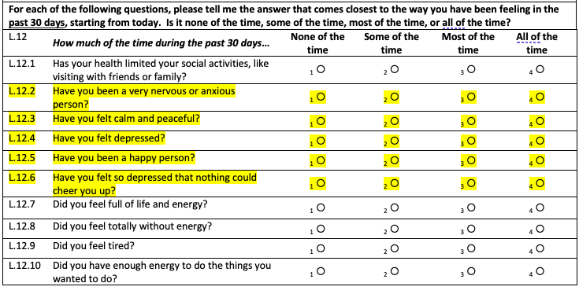

Mental Health Subscale survey questions

```r
# recoding TimePoint
# table(fisher_mh$TimePoint)
#
# fisher_mh <- fisher_mh %>%
#   mutate(period = recode(TimePoint,
#                          "0" = "1",
#                          "3" = "2",
#                          "6" = "3",
#                          "12" = "4",
#                          "18" = "5",
#                          "24" = "6",
#                          .default = "99"))
#
# table(fisher_mh$period)

fisher_mh_recode <- fisher_mh %>%
  mutate(depressed_l124 = recode(depressed_l124,
                                 "1" = "4",
                                 "2" = "3",
                                 "3" = "2",
                                 "4" = "1"),
         depressed_extra_l126 = recode(depressed_extra_l126,
                                 "1" = "4",
                                 "2" = "3",
                                 "3" = "2",
                                 "4" = "1"),
         anxious_l122 = recode(anxious_l122,
                                 "1" = "4",
                                 "2" = "3",
                                 "3" = "2",
                                 "4" = "1"))


fisher_mh_recode <- fisher_mh_recode %>%
  mutate(anxious_l122 = as.numeric(anxious_l122),
         depressed_l124  = as.numeric(depressed_l124),
         depressed_extra_l126 =as.numeric(depressed_extra_l126))
```

For each fisher at each time point, we need to combine the five subscale variables to create and scale the sub-scale.

```r
fisher_mh_recode <- fisher_mh_recode %>%
  mutate(total = (depressed_l124 + depressed_extra_l126 + anxious_l122 + calm_l123 + happy_l125))

minn <- 5
maxx <- 20
fisher_mh_recode <- fisher_mh_recode %>%
  mutate(mh_subscale = (100/(maxx-5)) * (total - minn))
```

Keeping only relevant variables

```r
fisher_mh_subscale <- fisher_mh_recode %>%
  select(ParticipantID, TimePoint, mh_subscale)
```

**COMBINE MORBIDITY AND FISHER BEHAVIOR DATA FRAMES**

```r
fishers <- full_join(fisher_mh_subscale, fishing_behavior, key = c("ParticipantID", "TimePoint"))
# cleaning up workspace before visualizing some things

rm(access, fisher_mh, fisher_mh_recode, fishing_behavior, fishing_behavior_f, fishing_behavior_nf, maxx, minn, mh_sub, morbidity, x, moshiv)

# using TimePoint to create "period" variable that we can treat as numeric for time series analysis
table(fishers$TimePoint, useNA = "always")

fishers <- fishers %>%
  mutate(period = as.numeric(recode(TimePoint,
                         "0" = "1",
                         "3" = "2",
                         "6" = "3",
                         "12" = "4",
                         "18" = "5",
                         "24" = "6",
                         .default = "99"))) # i think this sets missing values to 99

table(fishers$period)
```

**VISUALIZE FISHER MENTAL HEALTH DATA**

Key takeaways from plots/tables below, as of 12/24/2021:

- The variation is not impressive.
- The bulk of the sample is in the “some of the time” or “none of the time” categories, not “most of the time” or “all of the time”.
- The bulk of the movement seems to be between “some of the time” and “none of the time” too

Ideas for next steps:

- What do mothers’ mental health subscales look like?
  - How different are they from fishers?
  - Are they collected at every time point?

Plotting fisher mental health subscale over time.

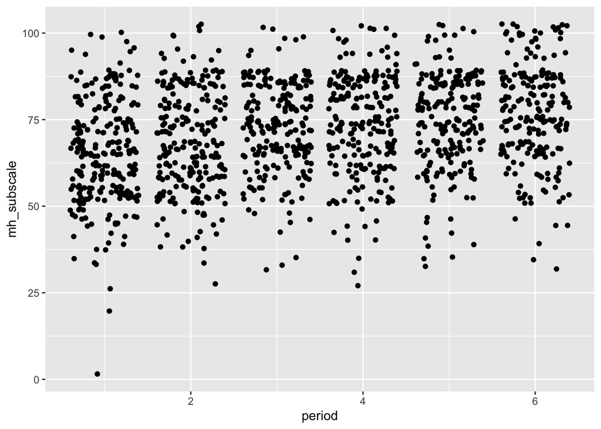

```r
ggplot(data = fishers) +
  geom_jitter(mapping = aes(x = period , y = mh_subscale))
```

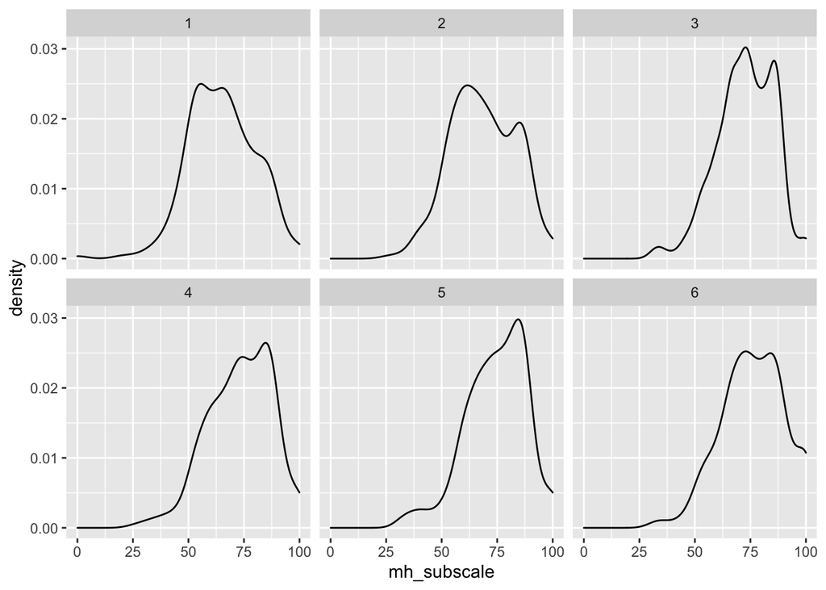

```r
ggsave("../images/mh_scatter_by_period.png")
histogram <- ggplot(fishers) +
  geom_histogram(mapping = aes(x = mh_subscale)) +
  facet_wrap(~ period)
ggsave("../images/mh_histogram_by_period.png")
ggplot(fishers) +
  geom_density(mapping = aes(x = mh_subscale)) +
  facet_wrap(~ period)
```

```r
ggsave("../images/mh_density_by_period.png")
```

I now want to know some summary statistics. What is the overall mean, the mean by period and the within-person mean.

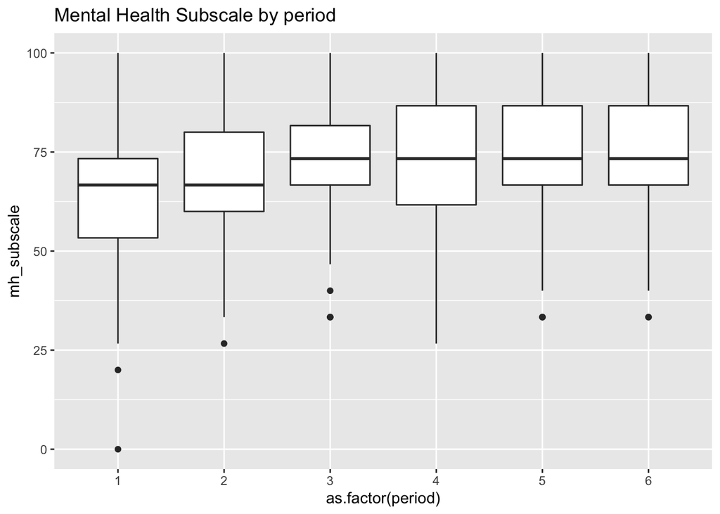

```r
# summary statistics by period
fishers %>%
  group_by(period) %>%
  summarise(mean = mean(mh_subscale), median = median(mh_subscale), sd = sd(mh_subscale)) %>%
  knitr::kable(caption = "Fisher MH subscale by period")

ggplot(fishers, aes(x = as.factor(period), y = mh_subscale)) +
  geom_boxplot() +
  labs(title = "Mental Health Subscale by period")
```

```r
ggsave("../images/mh_boxplot_by_period.png")
```

Fisher MH subscale by period

| period | mean | median | sd |
| --- | --- | --- | --- |
| 1 | NA | NA | NA |
| 2 | 68.72222 | 66.66667 | 14.58034 |
| 3 | 72.75758 | 73.33333 | 12.78443 |
| 4 | 73.42342 | 73.33333 | 14.31499 |
| 5 | NA | NA | NA |
| 6 | NA | NA | NA |

Quick calculation of within-household mean and SD.

```r
within_means <- fishers %>%
  group_by(ParticipantID) %>%
  summarise(mean = mean(mh_subscale), sd = sd(mh_subscale))
within_means %>%
  summarise(mean1 = mean(mean), sd = sd(mean)) %>%
  knitr::kable(caption = "Within-fisher mean and SD")
```

Within-fisher mean and SD

| mean1 | sd |
| --- | --- |
| NA | NA |

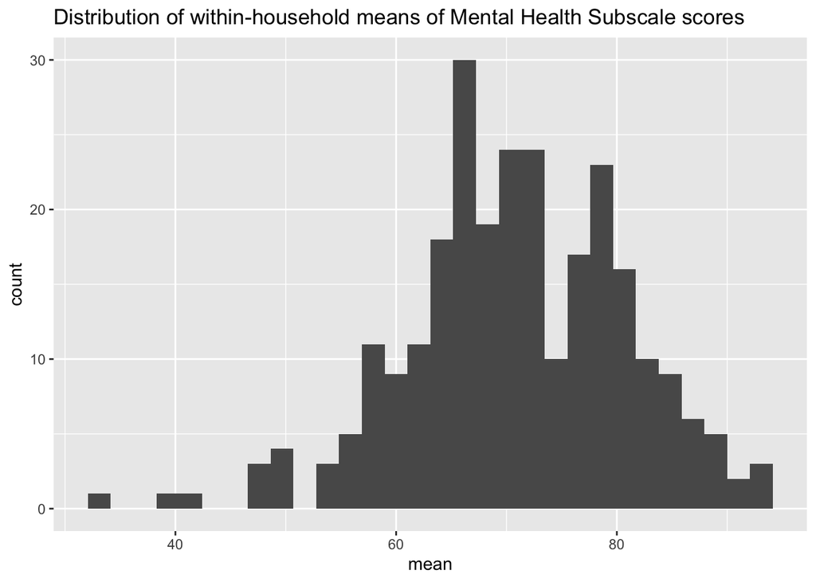

```r
ggplot(within_means) +
  geom_histogram(mapping = aes(x = mean)) +
  labs(title = "Distribution of within-household means of Mental Health Subscale scores")
```

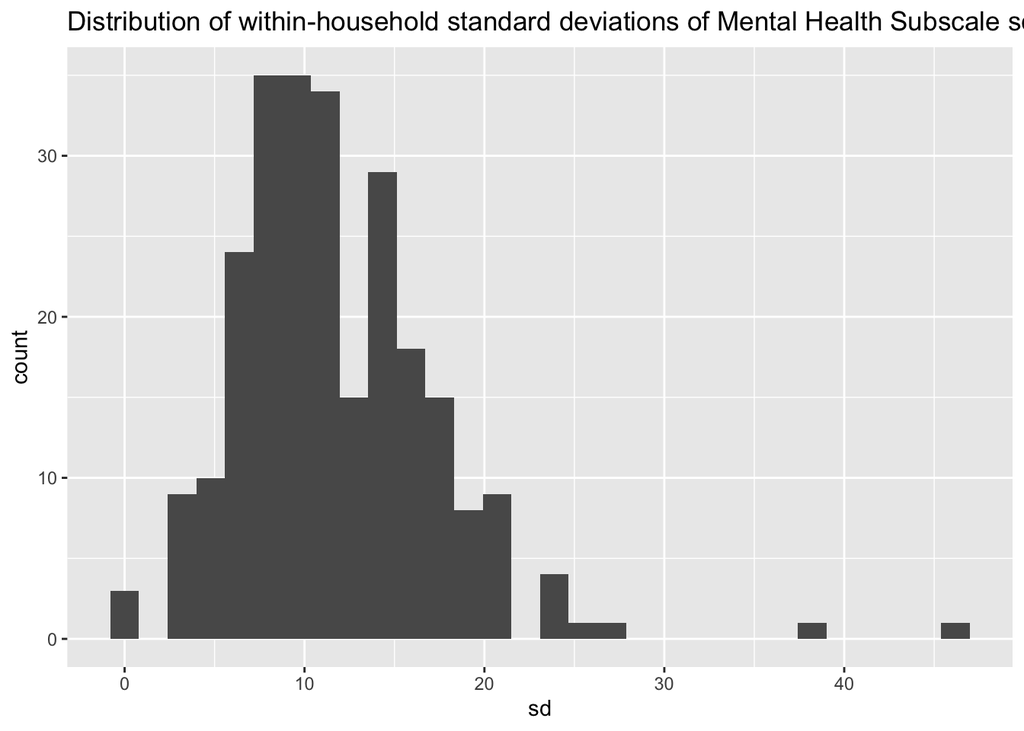

```r
ggplot(within_means) +
  geom_histogram(mapping = aes(x = sd)) +
  labs(title = "Distribution of within-household standard deviations of Mental Health Subscale scores")
```

**VISUALIZE FISHER BEHAVIOR**

Fishers’ decision to fish over time is pretty stable on average across fishers. On average, 60-70% of fishers fished in the past 3 months.

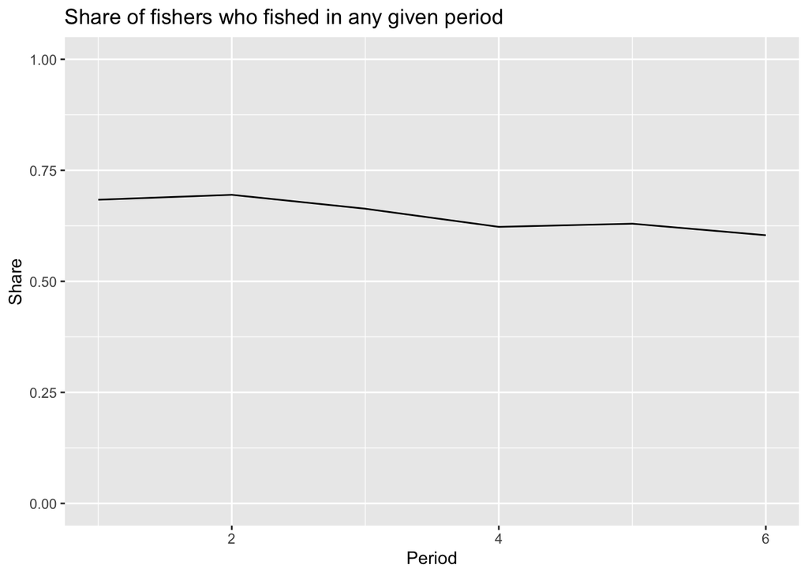

```r
# Examining missing values of fisher behavior. There are 15 cases with no clear pattern in terms of time point. Individual EOO92 is missing five time points.
fishers %>%
  filter(is.na(fished_i1)) # all missing cases of fished_i1 --> completely missing fisher behavior
fishers %>%
  filter(is.na(period))

# Filtering out missing fisher behavior data and summarizing by period
fishers %>%
  filter(!is.na(fished_i1)) %>%
  group_by(period) %>%
  summarise(mean = mean(fished_i1, na.rm = TRUE), sd = sd(fished_i1, na.rm = TRUE)) %>%
  ggplot(decision, mapping = aes(x = period, y = mean)) +
  geom_path(group = 1) +
  ylim(0, 1) +
  labs(title = "Share of fishers who fished in any given period", y = "Share", x = "Period")
```

Fishing behavior among those that fished

Among those that fished, there is a lot of variation in **perceptions of environmental changes** that affect fishing.

```r
print("In the last 3 months has there been an effect on the following: Environmental changes that affect fishing (examples: algae, water hyacinth)")
table(fishers$change_enviro_i310a, fishers$period, dnn=c("Yes/No", "Period"))
```

```
## [1] "In the last 3 months has there been an effect on the following: Environmental changes that affect fishing (examples: algae, water hyacinth)"
##       Period
## Yes/No   1   2   3   4   5   6
##      0  74  44  67  42  50  57
##      1  99 120  77  95  81  68
```

Variation in eports of **weather changes** affecting ability to fish

```r
print("Have any of the following shocks affected your ability to fish in the last 3 months? Weather changes")
table(fishers$shock_weather_i311, fishers$TimePoint, dnn=c("Weather Changes", "Period"))
```

[output not shown]

Limited reports of **water hyacinth**

```r
table(fishers$shock_hyacinth_i311, fishers$TimePoint, dnn=c("Hyacinth", "Period"))
```

[output not shown]

```r
table(fishers$shock_fishdecline_i311, fishers$TimePoint, dnn=c("Severe fish decline", "Period"))
```

[output not shown]

Fishing behavior among those that did not fish Among those that did not fish, very few cited **environmental changes that contributed to them not fishing**

```r
table(fishers$stop_decision_enviro_i245a, fishers$TimePoint, dnn=c("Yes/No", "Period"))
```

```
##       Period
## Yes/No   0   3   6  12  18  24
##      0 242 231 214 207 203 201
##      1  11   5   3  13   5   6
```

Did whether or not you are allowed to fish (regulations) affect your decision to stop fishing?

```r
table(fishers$stop_decision_regulation_i244a, fishers$TimePoint, dnn=c("Yes/No", "Period"))
```